# IE6400 Foundations for Data Analytics Engineering

# Fall 2023

### Module 1: Basic of Python - Part 1

[figure not shown]

#### What is Python?

Python is a computer language that many people like to use. It was made by a person named Guido van Rossum and was introduced in 1991. People use Python for many things, and one of those things is working with data.

In Data Analytics Engineering, Python is an extremely valuable tool. Here are some of the key reasons why Python is widely used in this field:

- Rich Ecosystem: Python has a vast ecosystem of libraries and frameworks that cater to data analytics and engineering needs. Some of the most popular ones include Pandas, NumPy, SciPy, Matplotlib, Seaborn, and Scikit-learn. These libraries provide data manipulation, analysis, visualization, and machine learning capabilities.
- Data Processing and Transformation: Python is excellent for data preprocessing and transformation tasks. Pandas, in particular, is a powerful library for working with structured data, allowing you to read, manipulate, and clean data efficiently.
- Data Visualization: Python offers a range of libraries for data visualization, such as Matplotlib and Seaborn. These tools make it easy to create informative plots and charts to understand and communicate insights from data.
- Statistical Analysis: Python's SciPy library provides a wide array of statistical functions and tools for conducting statistical analysis, hypothesis testing, and other statistical operations.
- Machine Learning: Python is a dominant language in the field of machine learning and artificial intelligence. Libraries like Scikit-learn, TensorFlow, and PyTorch are widely used for building and training machine learning models.
- Big Data Processing: Python can be used in conjunction with big data processing frameworks like Apache Spark and Hadoop through libraries like PySpark. This allows for the processing and analysis of large datasets.
- Database Connectivity: Python provides various libraries and packages for connecting to databases, including SQLAlchemy and psycopg2, making it easy to extract and load data from different data sources.
- Integration with Other Tools: Python can easily integrate with other data engineering tools and platforms, such as Apache Airflow for workflow automation and data pipeline management.
- Community and Documentation: Python has a large and active community of data analysts and engineers. This means that there is a wealth of documentation, tutorials, and community support available for anyone working in data analytics engineering.
- Cross-Platform Compatibility: Python is a cross-platform language, making it suitable for various operating systems, which is essential in a diverse data engineering environment.

Python is like a trusty toolbox for people who work with data. It helps you clean, organize, and understand your data, and it's a popular choice among people who do this kind of work.

#### 1. Variables

Variables are containers for storing data values.

#### Exercise 1.1 Creating Variables and Output Variables

Python has no command for declaring a variable.

A variable is created the moment you first assign a value to it.

```python
x = 1 # x is of type int
print(x)
```

```
1
```

```python
y = "NEU" # y is now of type str
print(y)
```

```
NEU
```

```python
x = "University"
print("Northeastern " + x)
```

```
Northeastern University
```

For numbers, the + character works as a mathematical operator:

```python
x = 5
y = 10
print(x + y)
```

```
15
```

You can use the + operator to output multiple variables:

```python
x = "Northeastern "
y = "University"
z =  x + y
print(z)
```

```
Northeastern University
```

In the print() function, you output multiple variables, separated by a comma:

```python
x = "Data"
y = "Analytics"
z = "Engineering"

print(x, y, z)
```

```
Data Analytics Engineering
```

```python
x = 5
y = "John"
print(x, y)
```

```
5 John
```

The best way to output multiple variables in the print() function is to separate them with commas, which even support different data types.

#### Exercise 1.2 Casting

If you want to specify the data type of a variable, this can be done with casting.

```python
x = int(1)   # x will be 1
y = int(2.8) # y will be 2
z = int("3") # z will be 3

print(x)
print(y)
print(z)
```

```
1
2
3
```

```python
x = float(1)     # x will be 1.0
y = float(2.8)   # y will be 2.8
z = float("3")   # z will be 3.0
w = float("4.2") # w will be 4.2

print(x)
print(y)
print(z)
print(w)
```

```
1.0
2.8
3.0
4.2
```

```python
x = str("S1") # x will be 's1'
y = str(2)    # y will be '2'
z = str(3.0)  # z will be '3.0'

print(x)
print(y)
print(z)
```

```
S1
2
3.0
```

```python
x = str(3)    # x will be '3'
y = int(3)    # y will be 3
z = float(3)  # z will be 3.0

print(x)
print(y)
print(z)
```

```
3
3
3.0
```

#### Exercise 1.3 Getting the Type

You can get the data type of a variable with the type() function.

```python
x = 1    # int
y = 2.8  # float
z = 1j   # complex
name = "Northeastern University"

print(type(x))
print(type(y))
print(type(z))
print(type(name))
```

```
<class 'int'>
<class 'float'>
<class 'complex'>
<class 'str'>
```

```python
x = 1
y = 35656222554887711
z = -3255522

print(type(x))
print(type(y))
print(type(z))
```

```
<class 'int'>
<class 'int'>
<class 'int'>
```

```python
x = 1.10
y = 1.0
z = -35.59

print(type(x))
print(type(y))
print(type(z))
```

```
<class 'float'>
<class 'float'>
<class 'float'>
```

```python
x = 35e3
y = 12E4
z = -87.7e100

print(type(x))
print(type(y))
print(type(z))
```

```
<class 'float'>
<class 'float'>
<class 'float'>
```

```python
x = 3+5j
y = 5j
z = -5j

print(type(x))
print(type(y))
print(type(z))
```

```
<class 'complex'>
<class 'complex'>
<class 'complex'>
```

#### Exercise 1.4 Single or Double Quotes?

String variables can be declared either by using single or double quotes:

```python
x = "John"
print(x)
# double quotes are the same as single quotes:
x = 'John'
print(x)
```

```
John
John
```

#### Exercise 1.5 Case-Sensitive

Variable names are case-sensitive.

```python
a = 4
A = "Sally"

print(a)
print(A)
```

```
4
Sally
```

The result showed that 'A' would not overwrite 'a'

#### Exercise 1.6 Many Values to Multiple Variables

Python allows you to assign values to multiple variables in one line:

```python
x, y, z = "Orange", "Banana", "Cherry"

print(x)
print(y)
print(z)
```

```
Orange
Banana
Cherry
```

Make sure the number of variables matches the number of values, or else you will get an error.

#### Exercise 1.7 One Value to Multiple Variables

And you can assign the same value to multiple variables in one line:

```python
x = y = z = "Orange"

print(x)
print(y)
print(z)
```

```
Orange
Orange
Orange
```

#### Exercise 1.8 Unpack a Collection

If you have a collection of values in a list, tuple etc. Python allows you to extract the values into variables. This is called unpacking.

```python
fruits = ["apple", "banana", "cherry"]
x, y, z = fruits

print(fruits)
print(x)
print(y)
print(z)
```

```
['apple', 'banana', 'cherry']
apple
banana
cherry
```

#### 2. Global Variables

Variables that are created outside of a function (as in all of the examples above) are known as global variables.

Global variables can be used by everyone, both inside of functions and outside.

#### Exercise 1.9 Create a variable outside of a function, and use it inside the function

```python
x = "University"

def myfunc():
    print("Northeastern " + x)

myfunc()
```

```
Northeastern University
```

If you create a variable with the same name inside a function, this variable will be local, and can only be used inside the function. The global variable with the same name will remain as it was, global and with the original value.

```python
x = "University"

def myfunc():
    x = "College"
    print("Northeastern " + x)

myfunc()

print("Northeastern " + x)
```

```
Northeastern College
Northeastern University
```

#### Exercise 1.10 The global Keyword

Normally, when you create a variable inside a function, that variable is local, and can only be used inside that function.

To create a global variable inside a function, you can use the global keyword.

If you use the global keyword, the variable belongs to the global scope:

```python
def myfunc():
    global x
    x = "University"

myfunc()

print("Northeastern " + x)
```

```
Northeastern University
```

Also, use the global keyword if you want to change a global variable inside a function.

To change the value of a global variable inside a function, refer to the variable by using the global keyword:

```python
x = "College"

def myfunc():
    global x
    x = "University"

myfunc()

print("Northeastern " + x)
```

```
Northeastern University
```

#### 3. Python Strings

Strings in python are surrounded by either single quotation marks, or double quotation marks.

'hello' is the same as "hello".

#### Exercise 1.11 Multiline Strings

You can assign a multiline string to a variable by using three quotes:

```python
a = """DAE Program,
Northeastern University,
Boston Campus
USA."""

print(a)
```

```
DAE Program,
Northeastern University,
Boston Campus
USA.
```

Or three single quotes:

```python
a = '''DAE Program,
Northeastern University,
Boston Campus
USA.'''

print(a)
```

```
DAE Program,
Northeastern University,
Boston Campus
USA.
```

In the result, the line breaks are inserted at the same position as in the code.

#### Exercise 1.12 Strings are Arrays

Like many other popular programming languages, strings in Python are arrays of bytes representing unicode characters.

However, Python does not have a character data type, a single character is simply a string with a length of 1.

Square brackets can be used to access elements of the string.

Get the character at position 13 (remember that the first character has the position 0):

```python
a = "Northeastern University"
print(a[13])
```

```
U
```

#### Exercise 1.13 Looping Through a String

Since strings are arrays, we can loop through the characters in a string, with a for loop.

Loop through the letters in the word "NORTHEASTERN":

```python
for x in "NORTHEASTERN":
    print(x)
```

```
N
O
R
T
H
E
A
S
T
E
R
N
```

#### Exercise 1.14 String Length

To get the length of a string, use the len() function.

The len() function returns the length of a string:

```python
a = "NORTHEASTERN"
print(len(a))
```

```
12
```

#### Exercise 1.15 Check String

To check if a certain phrase or character is present in a string, we can use the keyword in.

Check if "Engineering" is present in the following text:

```python
txt = "Data Analytics Engineering"
print("Engineering" in txt)
```

```
True
```

Use it in an if statement:

Print only if "Engineering" is present:

```python
txt = "Data Analytics Engineering"
if "Engineering" in txt:
    print("Yes, 'Engineering' is present.")
```

```
Yes, 'Engineering' is present.
```

#### Exercise 1.16 Check if NOT

To check if a certain phrase or character is NOT present in a string, we can use the keyword not in.

Check if "NEU" is NOT present in the following text:

```python
txt = "Data Analytics Engineering"
print("NEU" not in txt)
```

```
True
```

Use it in an if statement:

print only if "NEU" is NOT present:

```python
txt = "Data Analytics Engineering"
if "NEU" not in txt:
    print("No, 'NEU' is NOT present.")
```

```
No, 'NEU' is NOT present.
```

#### Exercise 1.16 Slicing Strings

You can return a range of characters by using the slice syntax.

Specify the start index and the end index, separated by a colon, to return a part of the string.

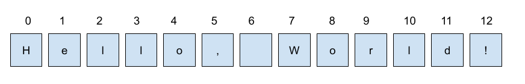

Get the characters from position 7 to position 12:

```python
b = "Hello, World!"
print(b[7:12])
```

```
World
```

Note: The first character has an index of 0. The end position is not included.

#### Exercise 1.17 Slice From the Start

By leaving out the start index, the range will start at the first character:

Get the characters from the start to position 5

```python
b = "Hello, World!"
print(b[:5])
```

```
Hello
```

#### Exercise 1.18 Slice To the End

By leaving out the end index, the range will go to the end:

```python
b = "Hello, World!"
print(b[7:])
```

```
World!
```

#### Exercise 1.19 Negative Indexing

Use negative indexes to start the slice from the end of the string:

Get the characters:

From: "A" in "DataAnalyticsEngineering" (position -20)

To, but not included: "E" in "DataAnalyticsEngineering" (position -11):

```python
b = "DataAnalyticsEngineering"
print(b[-20:-11])
```

```
Analytics
```

#### Exercise 1.20 Modify Strings

Python has a set of built-in methods that you can use on strings.

#### Upper Case

The upper() method returns the string in upper case:

```python
a = "Northeastern University"
print(a.upper())
```

```
NORTHEASTERN UNIVERSITY
```

#### Lower Case

The lower() method returns the string in lower case:

```python
a = "NORTHEASTERN UNIVERSITY"
print(a.lower())
```

```
northeastern university
```

#### Remove Whitespace

Whitespace is the space before and/or after the actual text, and very often you want to remove this space.

The strip() method removes any whitespace from the beginning or the end:

```python
a = "  Northeastern University   "
print(a)
print(a.strip())
```

```
  Northeastern University
Northeastern University
```

Note that strip does not remove whitespace everywhere, only at the beginning and end.

#### Replace String

The replace() method replaces a string with another string:

```python
a = "Northeastern University"
print(a.replace("University", "College"))
```

```
Northeastern College
```

#### Split String

The split() method returns a list where the text between the specified separator becomes the list items.

The split() method splits the string into substrings if it finds instances of the separator:

```python
a = "DAE,Northeastern University"
print(a.split(","))
```

```
['DAE', 'Northeastern University']
```

#### Exercise 1.21 String Concatenation

To concatenate, or combine, two strings you can use the + operator.

```python
a = "Northeastern"
b = "University"
c = a + b
print(c)
```

```
NortheasternUniversity
```

To add a space between them, add a " ":

```python
a = "Northeastern"
b = "University"
c = a + " " + b
print(c)
```

```
Northeastern University
```

#### Exercise 1.22 String Format

As we learned in the Python Variables, we cannot combine strings and numbers. But we can combine strings and numbers using the format() method!

The format() method takes the passed arguments, formats them, and places them in the string where the Brace placeholders {} are:

Use the format() method to insert numbers into strings:

```python
age = 2025
txt = "We are the DAE student, and we are the class of {}"
print(txt.format(age))
```

```
We are the DAE student, and we are the class of 2025
```

The format() method takes unlimited number of arguments, and are placed into the respective placeholders:

```python
quantity = 3
itemno = 567
price = 49.95
myorder = "I want {} pieces of item {} for {} dollars."
print(myorder.format(quantity, itemno, price))
```

```
I want 3 pieces of item 567 for 49.95 dollars.
```

You can use index numbers {0} to be sure the arguments are placed in the correct placeholders:

```python
quantity = 3
itemno = 567
price = 49.95
myorder = "I want to pay {2} dollars for {0} pieces of item {1}."
print(myorder.format(quantity, itemno, price))
```

```
I want to pay 49.95 dollars for 3 pieces of item 567.
```

#### Exercise 1.23 Escape Character

To insert characters that are illegal in a string, use an escape character.

An escape character is a backslash \ followed by the character you want to insert.

An example of an illegal character is a double quote inside a string that is surrounded by double quotes. You will get an error if you use double quotes inside a string that is surrounded by double quotes.

To fix this problem, use the escape character \":

```python
txt = "We are the so-called \"Husky\" at Northeastern University."
print(txt)
```

```
We are the so-called "Husky" at Northeastern University.
```

#### 4. Python Booleans

Booleans represent one of two values: True or False.

#### Exercise 1.24 Boolean Values

In programming you often need to know if an expression is True or False.

You can evaluate any expression in Python, and get one of two answers, True or False.

When you compare two values, the expression is evaluated and Python returns the Boolean answer:

```python
1==2
```

```
False
```

```python
x="aBC"
y="ABC"
x==y
```

```
False
```

```python
# Createing X variable where x = 2
x=2
```

```python
x<1 and x>3
```

```
False
```

```python
x<1 and x==3
```

```
False
```

```python
x<1 or x==2
```

```
True
```

```python
x=1
y=2
x is y
```

```
False
```

```python
x="abcd"
y="abc"
x in y
```

```
False
```

#### 5. Python Operators

Operators are used to perform operations on variables and values.

Python divides the operators in the following groups:

- Arithmetic operators
- Assignment operators
- Comparison operators
- Logical operators
- Identity operators
- Membership operators
- Bitwise operators

#### Python Arithmetic Operators

Arithmetic operators are used with numeric values to perform common mathematical operations:

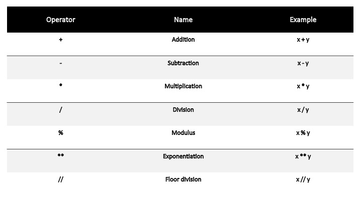

#### Exercise 1.25 Arithmetic Operators

```python
1+1
```

```
2
```

```python
2**3
```

```
8
```

```python
2*3
```

```
6
```

#### Python Assignment Operators

Assignment operators are used to assign values to variables:

#### Exercise 1.26 Assignment Operators

```python
x = 5
print(x)
```

```
5
```

```python
x += 3    # x = 5 + 3
print(x)
```

```
8
```

```python
x /= 8   # x = 8 / 8
print(x)
```

```
1.0
```

#### Python Comparison Operators

Comparison operators are used to compare two values:

#### Exercise 1.27 Comparison Operators

```python
1 == 2
```

```
False
```

```python
1 != 2
```

```
True
```

```python
1 < 2
```

```
True
```

```python
x = "aBC"
y = "ABC"
x == y
```

```
False
```

#### 6. Python Lists

Lists are used to store multiple items in a single variable.

Lists are one of 4 built-in data types in Python used to store collections of data, the other 3 are Tuple, Set, and Dictionary, all with different qualities and usage.

Lists are created using square brackets:

#### Exercise 1.28 Creating a list

List items are ordered, changeable, and allow duplicate values.

List items are indexed, the first item has index [0], the second item has index [1] etc.

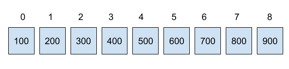

```python
thislist = [100,200,300,400,500,600,700,800,900]
print(thislist)
```

```
[100, 200, 300, 400, 500, 600, 700, 800, 900]
```

When we say that lists are ordered, it means that the items have a defined order, and that order will not change.

If you add new items to a list, the new items will be placed at the end of the list.

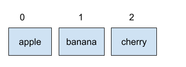

```python
thislist = ["apple", "banana", "cherry"]
print(thislist)
```

```
['apple', 'banana', 'cherry']
```

```python
thislist = ["apple", "banana", "cherry"]
type(thislist)
```

```
list
```

```python
thislist = [1,2,3]
type(thislist)
```

```
list
```

#### Exercise 1.29 Allow Duplicates

Since lists are indexed, lists can have items with the same value:

```python
thislist = ["apple", "banana", "cherry", "apple", "cherry"]
print(thislist)
```

```
['apple', 'banana', 'cherry', 'apple', 'cherry']
```

#### Exercise 1.30 List Length

To determine how many items a list has, use the len() function:

Print the number of items in the list:

```python
thislist = ["apple", "banana", "cherry"]
print(len(thislist))
```

```
3
```

#### Exercise 1.31 List Items - Data Types

List items can be of any data type:

String, int and boolean data types:

```python
list1 = ["apple", "banana", "cherry"]
print(list1)
```

```
['apple', 'banana', 'cherry']
```

```python
list2 = [1, 5, 7, 9, 3]
print(list2)
```

```
[1, 5, 7, 9, 3]
```

```python
list3 = [True, False, False]
print(list3)
```

```
[True, False, False]
```

A list can contain different data types:

```python
list4 = ["abc", 34, True, 40, "male"]
print(list4)
```

```
['abc', 34, True, 40, 'male']
```

#### Exercise 1.32 Access List Items

List items are indexed and you can access them by referring to the index number:

```python
thislist = ["apple", "banana", "cherry"]
print(thislist[1])
```

```
banana
```

Note that The first item has an index 0.

#### Negative Indexing:

Negative indexing means start from the end

-1 refers to the last item, -2 refers to the second last item etc.

```python
thislist = ["apple", "banana", "cherry"]
print(thislist[-1])
```

```
cherry
```

Printed the last item of the list.

#### Range of Indexes

You can specify a range of indexes by specifying where to start and where to end the range.

When specifying a range, the return value will be a new list with the specified items.

```python
thislist = ["apple", "banana", "cherry", "orange", "kiwi", "melon", "mango"]
print(thislist[2:5])
```

```
['cherry', 'orange', 'kiwi']
```

Returned the third, fourth, and fifth item. Note that the search started at index 2 (included) and end at index 5 (not included).

By leaving out the start value, the range will start at the first item:

This example returns the items from the beginning to, but NOT including, index 5 "melon":

```python
thislist = ["apple", "banana", "cherry", "orange", "kiwi", "melon", "mango"]
print(thislist[:5])
```

```
['apple', 'banana', 'cherry', 'orange', 'kiwi']
```

By leaving out the end value, the range will go on to the end of the list:

This example returns the items from "cherry" to the end:

```python
thislist = ["apple", "banana", "cherry", "orange", "kiwi", "melon", "mango"]
print(thislist[2:])
```

```
['cherry', 'orange', 'kiwi', 'melon', 'mango']
```

#### Range of Negative Indexes

Specify negative indexes if you want to start the search from the end of the list:

```python
thislist = ["apple", "banana", "cherry", "orange", "kiwi", "melon", "mango"]
print(thislist[-4:-1])
```

```
['orange', 'kiwi', 'melon']
```

This example returns the items from "orange" (-4) to, but NOT including "mango" (-1):

#### Exercise 1.33 Check if Item Exists

To determine if a specified item is present in a list use the in keyword:

Check if "apple" is present in the list:

```python
thislist = ["apple", "banana", "cherry"]
if "apple" in thislist:
    print("Yes, 'apple' is in the fruits list")
```

```
Yes, 'apple' is in the fruits list
```

#### Exercise 1.34 Change Item Value

To change the value of a specific item, refer to the index number:

Change the second item:

```python
thislist = ["apple", "banana", "cherry"]
thislist[1] = "blackcurrant"
print(thislist)
```

```
['apple', 'blackcurrant', 'cherry']
```

#### Change a Range of Item Values

To change the value of items within a specific range, define a list with the new values, and refer to the range of index numbers where you want to insert the new values:

Change the values "banana" and "cherry" with the values "blackcurrant" and "watermelon":

```python
thislist = ["apple", "banana", "cherry", "orange", "kiwi", "mango"]
thislist[1:3] = ["blackcurrant", "watermelon"]
print(thislist)
```

```
['apple', 'blackcurrant', 'watermelon', 'orange', 'kiwi', 'mango']
```

If you insert more items than you replace, the new items will be inserted where you specified, and the remaining items will move accordingly:

Change the second value by replacing it with two new values:

```python
thislist = ["apple", "banana", "cherry"]
thislist[1:2] = ["blackcurrant", "watermelon"]
print(thislist)
```

```
['apple', 'blackcurrant', 'watermelon', 'cherry']
```

Note that the length of the list will change when the number of items inserted does not match the number of items replaced.

If you insert less items than you replace, the new items will be inserted where you specified, and the remaining items will move accordingly:

Change the second and third value by replacing it with one value:

```python
thislist = ["apple", "banana", "cherry"]
thislist[1:3] = ["watermelon"]
print(thislist)
```

```
['apple', 'watermelon']
```

#### Exercise 1.35 Insert Items

To insert a new list item, without replacing any of the existing values, we can use the insert() method.

The insert() method inserts an item at the specified index:

Insert "watermelon" as the third item:

```python
thislist = ["apple", "banana", "cherry"]
thislist.insert(2, "watermelon")
print(thislist)
```

```
['apple', 'banana', 'watermelon', 'cherry']
```

As a result, the list will now contain 4 items.

#### Exercise 1.36 Extend List

To append elements from another list to the current list, use the extend() method.

Add the elements of tropical to thislist:

```python
thislist = ["apple", "banana", "cherry"]
tropical = ["mango", "pineapple", "papaya"]
thislist.extend(tropical)
print(thislist)
```

```
['apple', 'banana', 'cherry', 'mango', 'pineapple', 'papaya']
```

The elements will be added to the end of the list.

#### Exercise 1.37 Remove Specified Item

The remove() method removes the specified item.

```python
thislist = ["apple", "banana", "cherry"]
thislist.remove("banana")
print(thislist)
```

```
['apple', 'cherry']
```

Removed "banana"

If there are more than one item with the specified value, the remove() method removes the first occurance:

```python
thislist = ["apple", "banana", "cherry", "banana", "kiwi"]
thislist.remove("banana")
print(thislist)
```

```
['apple', 'cherry', 'banana', 'kiwi']
```

Removed the first occurance of "banana"

#### Exercise 1.38 Remove Specified Index

The pop() method removes the specified index.

Remove the second item:

```python
thislist = ["apple", "banana", "cherry"]
thislist.pop(1)
print(thislist)
```

```
['apple', 'cherry']
```

If you do not specify the index, the pop() method removes the last item.

```python
thislist = ["apple", "banana", "cherry"]
thislist.pop()
print(thislist)
```

```
['apple', 'banana']
```

Removed the last item!

#### Exercise 1.39 Remove the list

The del keyword can also delete the list completely.

```python
thislist = ["apple", "banana", "cherry"]
del thislist
```

```python
#print(thislist)
```

#### Exercise 1.40 Clear the List

The clear() method empties the list.

The list still remains, but it has no content.

```python
thislist = ["apple", "banana", "cherry"]
thislist.clear()
print(thislist)
```

```
[]
```

#### Exercise 1.41 Sort Lists

List objects have a sort() method that will sort the list alphanumerically, ascending, by default.

Sort the list alphabetically:

```python
thislist = ["orange", "mango", "kiwi", "pineapple", "banana"]
thislist.sort()
print(thislist)
```

```
['banana', 'kiwi', 'mango', 'orange', 'pineapple']
```

Sort the list numerically:

```python
thislist = [100, 50, 65, 82, 23]
thislist.sort()
print(thislist)
```

```
[23, 50, 65, 82, 100]
```

#### Sort Descending

To sort descending, use the keyword argument reverse = True:

```python
thislist = ["orange", "mango", "kiwi", "pineapple", "banana"]
thislist.sort(reverse = True)
print(thislist)
```

```
['pineapple', 'orange', 'mango', 'kiwi', 'banana']
```

```python
thislist = [100, 50, 65, 82, 23]
thislist.sort(reverse = True)
print(thislist)
```

```
[100, 82, 65, 50, 23]
```

#### Exercise 1.42 Reverse Order

The reverse() method reverses the current sorting order of the elements.

```python
thislist = ["banana", "Orange", "Kiwi", "cherry"]
thislist.reverse()
print(thislist)
```

```
['cherry', 'Kiwi', 'Orange', 'banana']
```

#### Exercise 1.43 Copy a List

You cannot copy a list simply by typing list2 = list1, because: list2 will only be a reference to list1, and changes made in list1 will automatically also be made in list2.

There are ways to make a copy, one way is to use the built-in List method copy().

Make a copy of a list with the copy() method:

```python
thislist = ["apple", "banana", "cherry"]
mylist = thislist.copy()
print(mylist)
```

```
['apple', 'banana', 'cherry']
```

Another way to make a copy is to use the built-in method list().

```python
thislist = ["apple", "banana", "cherry"]
mylist = list(thislist)
print(mylist)
```

```
['apple', 'banana', 'cherry']
```

#### Exercise 1.44 Join Lists

There are several ways to join, or concatenate, two or more lists in Python.

One of the easiest ways are by using the + operator.

```python
list1 = ["a", "b", "c"]
list2 = [1, 2, 3]

list3 = list1 + list2
print(list3)
```

```
['a', 'b', 'c', 1, 2, 3]
```

Another way to join two lists is by appending all the items from list2 into list1, one by one:

Append list2 into list1:

```python
list1 = ["a", "b" , "c"]
list2 = [1, 2, 3]

for x in list2:
    list1.append(x)

print(list1)
```

```
['a', 'b', 'c', 1, 2, 3]
```

Or you can use the extend() method, where the purpose is to add elements from one list to another list:

```python
list1 = ["a", "b" , "c"]
list2 = [1, 2, 3]

list1.extend(list2)
print(list1)
```

```
['a', 'b', 'c', 1, 2, 3]
```

Revised Date: Sep 12th, 2023